# Effective Visualizations

Now that you know how to create graphics and visualizations in R, you are armed with powerful tools for scientific computing and analysis. With this power also comes great responsibility. Effective visualizations is an incredibly important aspect of scientific research and communication. There have been several books (see references) written about these principles. In class today we will be going through several case-studies trying to develop some expertise into making effective visualizations.

## Worksheet

**The worksheet questions for today are embedded into the class notes.**

You can download this Rmd file [here](https://github.com/STAT545-UBC/Classroom/raw/master/cm013.Rmd)

Note, there will be very little coding in-class today, but I’ve given you plenty of exercises in the form of a supplemental worksheet (linked at the bottom of this page) to practice with after class is over.

## Resources

1. [Fundamentals of Data Visualization](https://serialmentor.com/dataviz/introduction.html) by Claus Wilke.
2. [Visualization Analysis and Design](https://www-taylorfrancis-com.ezproxy.library.ubc.ca/books/9780429088902) by Tamara Munzner.
3. [STAT545.com - Effective Graphics](https://stat545.com/effective-graphs.html) by Jenny Bryan.
4. [ggplot2 book](https://ggplot2-book.org) by Hadley Wickam.
5. [Callingbull.org](https://callingbull.org/tools.html) by Carl T. Bergstrom and Jevin West.

## Part 1: Warm-up and pre-test [20 mins]

### Warmup:

Write some notes here about what “effective visualizations” means to you. Think of elements of good graphics and plots that you have seen - what makes them good or bad? Write 3-5 points.

1. Factors are placed in order
2. Use a proper type of plot: column, bar, point
3. Use colors that are easy to differentiate

### CQ01: Weekly hours for full-time employees

> Question: Evaluate the strength of the claim based on the data: “German workers are more motivated and work more hours than workers in other EU nations.” do not know Very strong, strong, weak, very week, do not know - Do not know.
- Main takeaway: We don’t know the sample size or SD; the difference has been “exaggerated” (the gaps between them are less than 1 hour).
- Another tip for more effective visualization: numbers on axis don’t need to appear again beside bars.

### CQ02: Average Global Temperature by year

> Question: For the years this temperature data is displayed, is there an appreciable increase in temperature?

### CQ03: Gun deaths in Florida

> Question: Evaluate the strength of the claim based on the data: “Soon after this legislation was passed, gun deaths sharply declined.”

> Very strong, strong, weak, very week, do not know - I chose don’t know but actually this is very weak!
- Main takeaway: The y axis starts from the maximum value instead of zero…So the gun shot actually rose.
- Other tips to make effective visualization:
1. Colors matter. Choose the color of background and plot wisely.
2. Don’t be creative about the axis or colors: make sure it fits normall people’s habits.

## Part 2: Extracting insight from visualizations [20 mins]

Great resource for selecting the right plot: https://www.data-to-viz.com/ ; encourage you all to consult it when choosing to visualize data.

What I can get from *Data to Viz*:

1. How to avoid overplotting (very useful)!
2. Codes for different plots

### Case Study 1: Context matters

Scales of y axis on the right and left are quite different (100-fold). If made on the same scale, autism should just stay static.

### Case Study 2: A case for pie charts

How can people finish 100m in negative time…

## Part 3: Principles of effective visualizations [20 mins]

We will be filling these principles in together as a class

- Not sure if my notes below fit this part, but I believe they are useful in designing plots.
1. Remove borders
2. Remove legend if things have already been stated in graph
3. Remove unnecessary colors (keep the color of the bar you want to emphasize)
4. Remove axis if things have already been stated in title
5. Remove bolding
6. Remove lines on the background
7. Lighten the axes (if needed)

### Make a great plot worse

Instructions: Below is a code chunk that shows an effective visualization. First, copy this code chunk into a new cell. Then, modify it to purposely make this chart “bad” by breaking the principles of effective visualization above. Your final chart still needs to run/compile and it should still produce a plot.

How many of the principles did you manage to break?

1. Hide raw data using `geom_point` instead of `geom_jitter`.
2. Hide plot title.
3. Change texts on x-axis from months to numbers, which are right but inconvenient to read.
4. Background is grey instead of white, which is fine but not as clear as before.
5. Delete all arguments in `theme`, which makes texts on axes smaller and hard to see clearly.

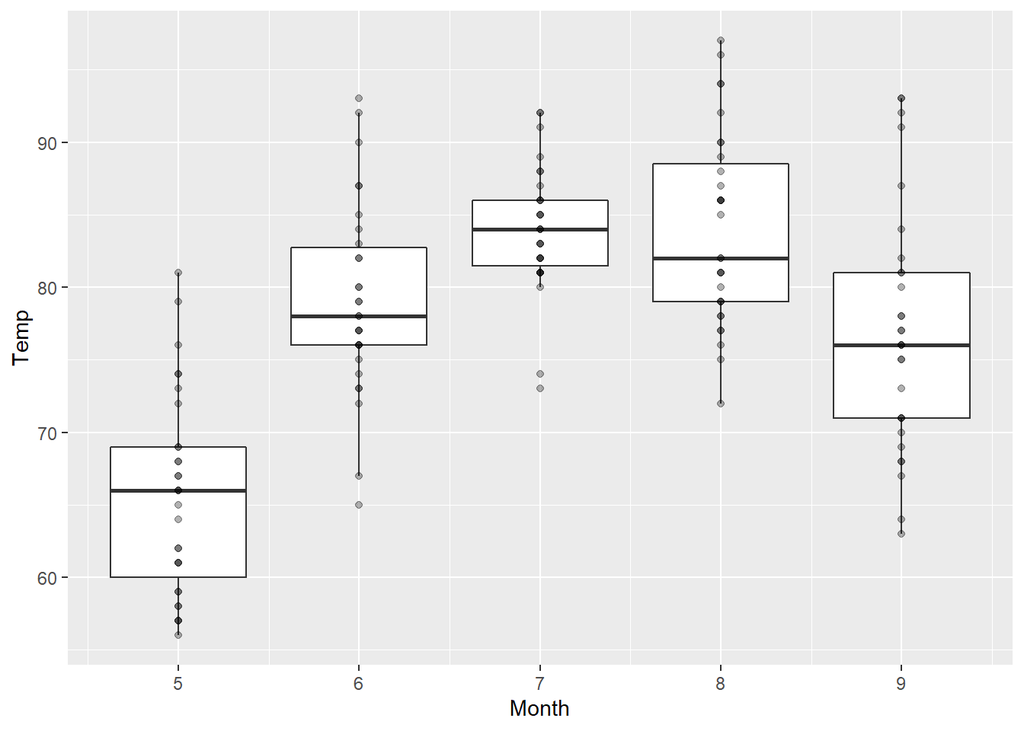

```r
suppressPackageStartupMessages(library(plotly))
suppressPackageStartupMessages(library(tidyverse))
ggplot(airquality, aes(`Month`, `Temp`, group = `Month`)) +
    geom_boxplot(outlier.shape = NA) +
    geom_point(alpha = 0.3)
```

## Plotly demo [10 mins]

Did you know that you can make interactive graphs and plots in R using the plotly library? We will show you a demo of what plotly is and why it’s useful, and then you can try converting a static ggplot graph into an interactive plotly graph.

```r
library(gapminder)
```

```r
p <- ggplot(gapminder, aes(x = gdpPercap, y = lifeExp, color = continent)) +
     geom_point()
# interactive
p %>%
ggplotly
```

[interactive chart not shown]

```r
#
gapminder %>%
  plot_ly(x = ~gdpPercap,
          y = ~lifeExp,
          color = ~continent,

          type = "scatter",
          mode = "markers") # line for line graph
```

[interactive chart not shown]

```r
Sys.setenv("plotly_username" = "qiyangqd")
Sys.setenv("plotly_api_key" = "AJPXMHEx1yXieA0VtkDM")
api_create(p, filename = "cm013-plotly")
```

```
## Found a grid already named: 'cm013-plotly Grid'. Since fileopt='overwrite', I'll try to update it
```

```
## Found a plot already named: 'cm013-plotly'. Since fileopt='overwrite', I'll try to update it
```

[interactive chart not shown]

```r
# Not sure why there is a big blank area above, but these lines can create a plot in my plotly when I knit them.
# successfully generated a public link.
```

This is a preview of what we’ll be doing in STAT 547 - making dynamic and interactive dashboards using R!

## Supplemental worksheet (Optional)

You are highly encouraged to the cm013 supplemental exercises worksheet. It is a great guide that will take you through Scales, Colours, and Themes in ggplot. There is also a short guided activity showing you how to make a ggplot interactive using plotly.